# Monetary policy and asset pricing - Assignment no. 4

Federico Vicentini

06/11/2022

## Exercise 1:

Now the exogenous endowment shock is a two states Markov process, defined as:

$$\frac{\Omega_{t}}{\Omega_{t-1}}=\omega_{t}\quad
with \; \omega_{t}\epsilon (h,l)$$

With the following symmetric transition matrix:

$$\Pi = \left[\begin{matrix}\phi &
(1-\phi) \\
(1-\phi) & \phi \\
\end{matrix}\right]$$

Let $\beta = 0.96$, $\gamma=2$, $h=1.05$, $l=0.97$ and $\phi=0.3$.

Knowing this, we cannot use the same 4-cases framework we’ve seen in class, as the probability of finding ourselves in state h or state l now depends on the state of the economy in the previous period.

Thus, we will have two different yield curves, conditional on the state of the Markov process we are starting with at time t. Let’s then compute the yield curve for each of the two cases.

## CASE 1: (t = state h)

In this case, we start in h at time t, so the probability matrix (at times $t+1$ and $t+2$) will look like this:

$$\left[\begin{matrix}\phi &
(\phi*\phi)+(1-\phi)*(1-\phi) \\
(1-\phi) & \phi*(1-\phi)+(1-\phi)*\phi\\
\end{matrix}\right]$$

Looking at the first column it’s obvious that, since we find ourselves in $h$ at time $t$, in time $t+1$ we will be still in $h$ with probability $\phi$ and we will switch to $l$ with probability $(1-\phi)$. Looking at the second column, we have to think about the ways through which we could find ourselves in h at time $t+2$: either we were in $h$ at time $t$ and we remained there (probability equal to $(\phi*\phi)$) or we were in $l$ at time $t$ and we switched states (probability equal to $(1-\phi)*(1-phi)$). Summing the two probabilities we find the total probability of finding ourselves in state $h$ at time $t+2$. The same exact reasoning applies to the probability of finding ourselves in state $l$.

We can rewrite it as:

$$\left[\begin{matrix}\phi &
2\phi^{2}+1-2\phi\\
(1-\phi) & 2\phi(1-\phi)\\
\end{matrix}\right]$$

Then, we compute the yield at time $t+1$ and $t+2$ using the following code and the two equations:

$$y_{t+1}=-ln
\left(\beta*\left(p_{1}(h)*(h)^{-\gamma} +
p_{1}(l)*(l)^{-\gamma}
\right)\right)$$
$$y_{t+2}=-\frac{1}{2}ln \left(\beta^{2}
\left(p_{1}(h) p_{2}(h) (h^{2})^{-\gamma} +
p_{1}(l) p_{2}(l) (l^{2})^{-\gamma} +
p_{1}(h) p_{2}(l) (hl)^{-\gamma} +
p_{1}(l) p_{2}(h) (lh)^{-\gamma}
\right)\right)$$

We wanted also to have a measure of the short-term interest rate in period t. In the real world, this is the overnight interest rate, set by the Central Bank. To make an approximation, we used the same equation used for $y_{t+1}$ setting $p_{1}(h)=1$ since we know we are in $h$ at time $t$. Also, $\beta$ has exponent $0$ so it is equal to $1$. Thus, equation for our “short-term” interest rate is:

$$y_{t}=-ln
\left((h)^{-\gamma}\right)$$

Let’s look now at the code and the output:

```r
#CASE 1:
#In this case we find ourselves in h at time t

pi <- matrix(NA, 2,2)
pi[1,]=c(phi, 2*(phi)^2+1-2*phi)
pi[2,]=c(1-phi, (2*phi)-2*(phi)^2)

yt_1=-log(beta*(pi[1,1]*(h)^(-gamma)+pi[2,1]*(l)^(-gamma)))
yt_2=-0.5*log(((beta)^2)*(pi[1,1]*pi[1,2]*(h*h)^(-gamma) +
                          pi[2,1]*pi[2,2]*(l*l)^(-gamma) +
                          pi[1,1]*pi[2,2]*(h*l)^(-gamma) +
                          pi[2,1]*pi[1,2]*(l*h)^(-gamma)))

yieldcurve=c(yt_1,yt_2)
plot(yieldcurve, type="o",  main="Yield curve with t = h",
                            xlab= "Time",
                            ylab= "Yield",
                            col="dark green")
```

[figure not shown]

```r
yt_0=-log((h)^(-gamma))
yieldcurve=c(yt_0,yt_1,yt_2)
plot(yieldcurve, type="o",  main="Yield curve with t = h",
                            xlab= "Time",
                            ylab= "Yield",
                            col="dark green")
```

[figure not shown]

```r
yieldcurve * 100
```

```
## [1] 9.75803283388641 2.48724826184924 4.68113204871125
```

In this case, the yield curve starts at about $9.75\%$, then it presents a downward slope going to $2.49\%$ in the second period (indicating the high probability of a recession in $t+1$) and then going up again to a yield of $4.68\%$ in $t+2$ (indicating the prediction of a recovery in the second period).

We observe that even if the curve predicts a recovery in the long term, does not return to the first-period yield level. We believe this is because in the starting period the state $h$ is certain, while in the second it is only slightly more likely than a recession (looking at our results, we have $58\%$ probability of being in the high state), thus the yield is lower.

## CASE 2: (t = state l)

In the second case the procedure remains exactly identical, but the two rows of the probability matrix are inverted with respect to the first case.

So, we report below the code and the related plots:

```r
#CASE 2:
#In this case we find ourselves in l at time t

pi2 <- matrix(NA, 2,2)
pi2[1,]=c(1-phi, (2*phi)-2*(phi)^2)
pi2[2,]=c(phi, 2*(phi)^2+1-2*phi)

yt_1l=-log(beta*(pi2[1,1]*(h)^(-gamma)+pi2[2,1]*(l)^(-gamma)))
yt_2l=-0.5*log(((beta)^2)*(pi2[1,1]*pi2[1,2]*(h*h)^(-gamma) +
                          pi2[2,1]*pi2[2,2]*(l*l)^(-gamma) +
                          pi2[1,1]*pi2[2,2]*(h*l)^(-gamma) +
                          pi2[2,1]*pi2[1,2]*(l*h)^(-gamma)))

yieldcurve_l=c(yt_1l,yt_2l)
plot(yieldcurve_l, type="o",  main="Yield curve with t = l",
                              xlab= "Time",
                              ylab= "Yield",
                              col="red")
```

[figure not shown]

```r
yt_0l=-log((l)^(-gamma))
yieldcurve_l=c(yt_0l,yt_1l,yt_2l)
plot(yieldcurve_l, type="o",  main= "Yield curve with t = l",
                              xlab= "Time",
                              ylab= "Yield",
                              col="red")
```

[figure not shown]

```r
yieldcurve_l * 100
```

```
## [1] -6.09184149694172  8.81607025538177  6.58013343114979
```

We observe that even if the curve predicts a recession in the long term, it does not return to the first-period yield level. We believe this is because in the starting period the state $l$ is certain, while in the second it is only slightly more likely than an expansion (looking at our results, we have $58\%$ probability of being in the low state), thus the yield is naturally higher.

Note that in both cases the yield $y_{t}$ is practically a “fictional” one. In the first case, the yield is much higher than what we would typically see in the real world economy, since we do not ever have the complete certainty of being in a high state of growth, thus the real yield is going to be much lower. In the second case, the yield is much lower than what we would observe. Also, let’s recall that in reality, these short-term interest rate are mandated by the CBs, not by the market itself.

## Comment on both cases

We can observe that, even if the the only difference in the probability matrix in the two cases are the inverted rows, the yields are not “inverted”. In fact, the yield curve of the first case is always below the one for the second case (excluding $y_{t}$).

[figure not shown]

In fact, we cannot even state that the slope of the curve is the same in absolute value. The two yield curves present different slopes, and we can motivate this by considering the fact that, since we are dealing with a two-period framework, losing $3\%$ and then gaining $5\%$ (which is the equivalent of ending up in $l$ and then going to $h$) does not result in the same gains as the opposite path (gaining $5\%$ and then losing $3\%$). If we add to this the fact that gains and losses are not equal in magnitude, we have a good explanation of why the two curves behave in a different way.

# Exercise 2

# Plot yield curves 2020

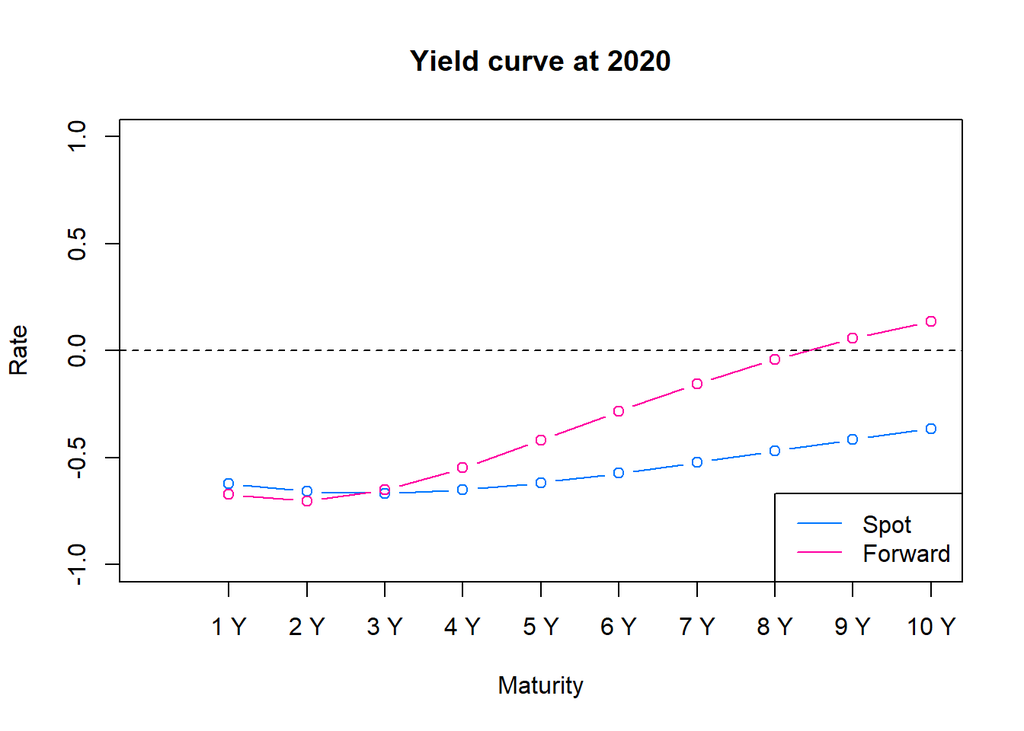

The plot above represents the spot and forward yield curve in July 1st, 2020. The spot yield is entirely in the negative area of interest rate due to the Asset Purchase Program (PEPP) put in place by the ECB in response to the first impacts of the Covid pandemic.  
Even the forward curve is negative until the 8Y maturity, reflecting how the ECB enlarged the APP program to face the pandemic in the EU, lowering the yield curve for the short maturities.

The curves are upward-sloping after 3Y, and the forward rate premium becomes higher as maturity increases, suggesting that agents had been expecting the recovery of consumption at the pre-covid level, a tightening in the monetary policy, or maybe higher inflation rates.

- $E[Inflation \; rates]$ -> inflation risk premium
- $E[Monetary \; policy]$ -> real rate risk premium

Hence, if investors see higher odds of a recession, the long-term inflation risk premium in Treasury bonds will fall. In contrast, an increase in the recession probability would increase the real rate risk premium asked by agents. One interpretation can be that if investors see a greater risk of recession, they will attribute a higher value to short-term assets that they can quickly liquidate to finance spending on goods and services. It seems reasonable because the covid pandemic had already broken out in July, and the prices incorporated the expectation of future covid measures that could hinder consumption.

# Plot yield curves 2022

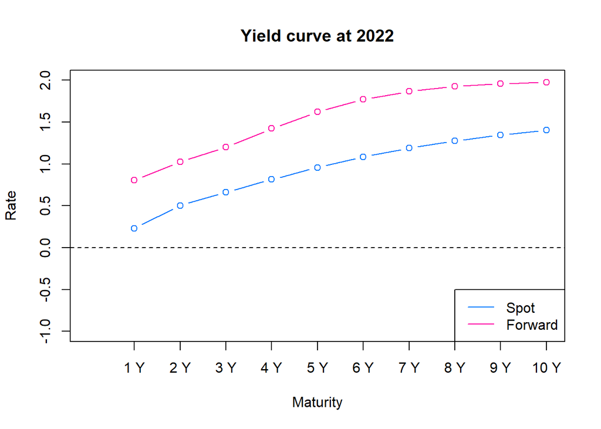